# In vitro protein binding microarray analysis with Zelda affinity

Kaelan (1028-02098-001-001)

September 21, 2022

# 1. Introduction

The goal of this analysis is to use protein binding microarray (PBM) data previously generated with the Rushlow and Hughes labs, in addition to our BPNet/ChromBPNet results, to study Zelda motif affinities associated with the different Zelda heptads. Note that we have reviewed previously described Zelda TAGteam motif affinities from the following publications:

1. Nien et al., PLOS Genetics, 2011: https://journals.plos.org/plosgenetics/article?id=10.1371/journal.pgen.1002339
2. Harrison et al., PLOS Genetics, 2011: https://journals.plos.org/plosgenetics/article?id=10.1371/journal.pgen.1002339
3. Harrison et al., Developmental Biology, 2010: https://www.sciencedirect.com/science/article/pii/S0012160610008468?via%3Dihub
4. Liang et al., Nature, 2008: https://www.nature.com/articles/nature07388

We will also plot the in silico analysis results that were generated as part of 8_acc_insilico_perturbs.ipynb, where motifs were injected at some distance away from other motifs and accessibility was predicted. Note that this analysis will cover Figure 3 a,b,h, and i. The rest of figure 3, including the Zelda depeltion analysis, will be in 13_*.rmd.

# 2. Computational Setup

```r
#Standard packages
library(rtracklayer) ; library(GenomicRanges); library(magrittr) ; library(Biostrings)
library(ggplot2) ; library(reshape2); library(plyranges); library(Rsamtools); library(ggpubr)
library(dplyr); library(data.table); library(patchwork); library(readr); library(testit); library(cowplot)

#KNITR Options
setwd("/l/Zeitlinger/ZeitlingerLab/Manuscripts/Zelda_and_Nucleosomes/Analysis/analysis/")
options(knitr.figure_dir="figures/12_pbm_w_affinities/", java.parameters = "- Xmx6g")

#Lab sources
source("scripts/r/granges_common.r")
source("scripts/r/metapeak_common.r")
source("scripts/r/knitr_common.r")
source("scripts/r/caching.r")
source("scripts/r/metapeak_functions.r")

#Specific sources
library(ggseqlogo)
library(BSgenome.Dmelanogaster.UCSC.dm6)
library(rhdf5)
source("scripts/r/motif_functions.r")

#Pre-existing variables
modisco_dir <- 'bpnet/modisco/fold1/'
tasks <- c('Zld','Dl','Twi','Bcd','Cad','GAF')
threads <- 5
bsgenome<-BSgenome.Dmelanogaster.UCSC.dm6
```

# 3. Import relevant data for this analysis

```r
# PBM data

## PBM E-scores:

pbm_e_rep1.df<-read.delim('/l/Zeitlinger/ZeitlingerLab/Manuscripts/Zelda_and_Nucleosomes/Analysis/data/pbm/Cterm/E_2016-02-04_12072_1M-ME_Standard_pEX0562.1_Zld.txt', sep="\t") %>%
  dplyr::mutate(type = 'pbm_rep1') %>%
  dplyr::rename(seq = `X.8mers`)
pbm_e_rep2.df<-read.delim('/l/Zeitlinger/ZeitlingerLab/Manuscripts/Zelda_and_Nucleosomes/Analysis/data/pbm/Cterm/E_2016-02-04_12088_1M-HK_Standard_pEX0562.2_Zld.txt', sep="\t") %>%
  dplyr::mutate(type = 'pbm_rep2') %>%
  dplyr::rename(seq = `X.8mers`)

pbm.e.df<-rbind(pbm_e_rep1.df, pbm_e_rep2.df) %>%
  dplyr::arrange(desc(all))

## PBM Z-scores:

pbm_z_rep1.df<-read.delim('/l/Zeitlinger/ZeitlingerLab/Manuscripts/Zelda_and_Nucleosomes/Analysis/data/pbm/Cterm/Z_2016-02-04_12072_1M-ME_Standard_pEX0562.1_Zld.txt', sep="\t") %>%
  dplyr::mutate(type = 'pbm_rep1') %>%
  dplyr::rename(seq = `X.8mers`)
pbm_z_rep2.df<-read.delim('/l/Zeitlinger/ZeitlingerLab/Manuscripts/Zelda_and_Nucleosomes/Analysis/data/pbm/Cterm/Z_2016-02-04_12088_1M-HK_Standard_pEX0562.2_Zld.txt', sep="\t") %>%
  dplyr::mutate(type = 'pbm_rep2') %>%
  dplyr::rename(seq = `X.8mers`)

pbm_z.df<-rbind(pbm_z_rep1.df, pbm_z_rep2.df) %>%
  dplyr::arrange(desc(all))

# Zelda motifs from BPNet-binding model

zld_motifs_ov.gr <- readr::read_tsv('/l/Zeitlinger/ZeitlingerLab/Manuscripts/Zelda_and_Nucleosomes/Analysis/analysis/tsv/mapped_motifs/all_instances_curated_1based.tsv.gz') %>%
  dplyr::filter(pattern_name == 'Zld') %>%
  makeGRangesFromDataFrame(keep.extra.columns = T, starts.in.df.are.0based = F) %>%
  plyranges::mutate(seq = getSeq(bsgenome, ., as.character = T))

# Motif affinity scores determined with marginalization

marg_bind.df <- readr::read_tsv('/l/Zeitlinger/ZeitlingerLab/Manuscripts/Zelda_and_Nucleosomes/Analysis/analysis/tsv/perturbs/binding/binding_zld_seq_freqs.tsv.gz') %>%
  as.data.frame()
marg_acc.df <- readr::read_tsv('/l/Zeitlinger/ZeitlingerLab/Manuscripts/Zelda_and_Nucleosomes/Analysis/analysis/tsv/perturbs/accessibility/accessibility_zld_seq_freqs.tsv.gz') %>%
  as.data.frame()
```

# 4. Plot sequences of all Zld motifs

```r
# Variables

motifs.df <- readr::read_tsv('/l/Zeitlinger/ZeitlingerLab/Manuscripts/Zelda_and_Nucleosomes/Analysis/analysis/tsv/mapped_motifs/all_instances_curated_1based.tsv.gz')
motifs_of_interest<-c('Zld', 'GAF', 'Cad', 'Dl','Twi','Bcd')
figure_filepath<-"/l/Zeitlinger/ZeitlingerLab/Manuscripts/Zelda_and_Nucleosomes/Analysis/analysis/figures/12_pbm_w_affinities"
window_size<-31

# Function

metaplots.list<-mclapply(motifs_of_interest, function(x){

  #Define and order motifs
  message(x)
  motif.df<-motifs.df %>%
    dplyr::filter(pattern_name == x) %>%
    dplyr::arrange(contrib_weighted) %>% #order by TF binding contribution
    dplyr::mutate(ordered_row = 1:n())
  motif.gr<-makeGRangesFromDataFrame(motif.df, keep.extra.columns = T)


  #Plot sequence of these motifs
  if(width(motif.gr[1]) %% 2 == 0){window_size<-30}else{window_size<-31}
  motif_resized.gr<-resize(motif.gr, window_size, 'center') %>%
    plyranges::mutate(seq = getSeq(bsgenome, ., as.character = T))
  motif_seq.df<-lapply(1:length(motif_resized.gr), function(x){
    split_vec<-strsplit(motif_resized.gr$seq[x], split="") %>% unlist
    df<-data.frame(nt=split_vec, position=1:length(split_vec), row=x, stringsAsFactors = F)
    return(df)
  }) %>% rbindlist %>%
    dplyr::mutate(position = position %>% as.character(.) %>% as.integer())

  seq.plot<-ggplot(motif_seq.df, aes(x=position, y=row, fill=nt))+
    ggrastr::geom_tile_rast()+
    scale_y_continuous(expand = c(0, 0), name = 'Motifs ordered by TF contrib.')+
    scale_x_continuous(expand = c(0, 0), name = 'Position across motif (bp)')+
    scale_fill_manual(values = c("#36982F", "#402CFD", "#FFB530", "#FC3437"), name="Nucleotide")+
    ggtitle('Sequences')+
    theme_classic()+
    theme(legend.position="bottom", panel.background = element_blank())

  ggsave(paste0(figure_filepath, '/', x, '_affinity_seq.png'),
         seq.plot, height = 6, width = 8)
  ggsave(paste0(figure_filepath, '/', x, '_affinity_seq.pdf'),
         seq.plot, height = 6, width = 8)

  #Plot logos
  grouped_motifs.gr<-motif.gr %>%
    plyranges::mutate(seq = getSeq(bsgenome, ., as.character = T),
                      seq_group = cut(ordered_row, breaks = 4, labels = c(1:4)))
  grouped_seqs.list<-lapply(4:1, function(x){
    grouped_motifs.gr %>% plyranges::filter(seq_group==x) %>%
      .$seq
  })
  names(grouped_seqs.list)<-4:1
  logo.plot<-ggseqlogo(grouped_seqs.list) + facet_wrap(~seq_group, ncol = 1) + ggtitle('Logos')

  ggsave(paste0(figure_filepath, '/', x, '_affinity_logo.png'),
         logo.plot, height = 6, width = 4)
  ggsave(paste0(figure_filepath, '/', x, '_affinity_logo.pdf'),
         logo.plot, height = 6, width = 4)

  motif_seq_vs_contrib.plot<-logo.plot + seq.plot  +
    plot_layout(nrow = 1, widths = c(.4, 1)) +
    plot_annotation(title = paste0(x, ', ordered by contrib'))

  ggsave(paste0(figure_filepath, '/', x, '_affinity_metaplots.png'),
         motif_seq_vs_contrib.plot, height = 6, width = 20)
  ggsave(paste0(figure_filepath, '/', x, '_affinity_metaplots.pdf'),
         motif_seq_vs_contrib.plot, height = 6, width = 20)
  return(motif_seq_vs_contrib.plot)
}, mc.cores = 2)
```

## 4.1. Plot accessibility heatmaps at all Zld motifs

### 4.1.1. Define function for atac heatmaps

```r
get_standard_heatmap_df<-function(regions.gr, sample, upstream=50, downstream=50, removal_threshold=.5, normalize_threshold=0.99){

  #Get signals across regions
  mat<-standard_metapeak_matrix(regions.gr = resize(regions.gr, 1, "start"), sample=sample, upstream=upstream, downstream=downstream)

  #Convert matrix to dataframe
  mat.tidy.df<-mat %>% as.data.table
  colnames(mat.tidy.df)<-c(-upstream:(downstream-1)) %>% as.character
  mat.tidy.df<-mat.tidy.df %>%
    dplyr::mutate(row_id = 1:nrow(.)) %>%
    melt.data.table(id.vars = c('row_id'), variable.name = 'position', value.name = 'reads') %>%
    dplyr::group_by(row_id) %>%
    dplyr::mutate(total_row_counts = sum(reads),
                  position = position %>% as.character(.) %>% as.integer(.))

  #Normalize matrix
  mat.tidy.df<-mat.tidy.df %>%
    # dplyr::group_by(row_sum_ordered) %>%
    dplyr::group_by(row_id) %>%
    dplyr::mutate(removal_threshold_val = quantile(reads, removal_threshold), #for each row, what is the quantile threshold?
                  above_removal_threshold = reads > removal_threshold_val, #for each row, which positions are above a quantile threshold?
                  reads_above_removal_threshold = ifelse(above_removal_threshold, reads, 0), #anything below the quantile threshold is zero
                  log2_reads_above_removal_threshold = log2(reads_above_removal_threshold + 1), #log2-scale the reads that remain
                  upper_threshold_val = quantile(reads, normalize_threshold), #for each row, what is the quantile threshold?
                  norm_reads_above_removal_threshold = pmin(reads/upper_threshold_val, 1) #max-scale the reads the remain to the upper threshold
                  )
  return(mat.tidy.df)
}
```

### 4.1.2. Plot summaries

```r
timepoints <- c('1to15','15to2','2to25','25to3')
alpha_value = 0.5
motifs_for_plotting <-c('Zld')

acc.list<-mclapply(motifs_for_plotting, function(x){

  #Define and order motifs
  message(x)
  motif.df<-motifs.df %>%
    dplyr::filter(pattern_name == x) %>%
    dplyr::arrange(contrib_weighted) %>% #order by TF binding contribution
    dplyr::mutate(ordered_row = 1:n())
  motif.gr<-makeGRangesFromDataFrame(motif.df, keep.extra.columns = T)

  #Define and order input coverage
  atac.bw<-Sys.glob('/l/Zeitlinger/ZeitlingerLab/Manuscripts/Zelda_and_Nucleosomes/Analysis/data/bw/dm6/atac/combined/orer_*_atac_combined_normalized.bw') %>% as.list()
  names(atac.bw)<-atac.bw %>% unlist %>% basename(.) %>% gsub('orer_', '', .) %>% gsub('_atac_combined_normalized.bw', '', .)

  #Plot ATAC coverage across regions
  obs_atac.df<-mclapply(names(atac.bw), function(x){
    df<-get_standard_heatmap_df(regions.gr = motif.gr, sample = atac.bw[[x]], upstream = 500, downstream = 501, removal_threshold = .7) %>%
      dplyr::mutate(timepoint = x)
  }, mc.cores = 4) %>% rbindlist %>%
    dplyr::mutate(timepoint = factor(timepoint, levels = timepoints))

  atac_heatmap.plot<-ggplot()+
    ggrastr::geom_tile_rast(data=obs_atac.df, aes(x=position, y=row_id, fill=log2_reads_above_removal_threshold))+
    scale_fill_gradientn(colors = c("white", '#edf2f7', '#dce5ef','#b8cbe0','#95b1d0','#7498c2','#5f89b9','#4e7cb1','#3e638e','#2f4b6a'),
                         name = "norm.\nsignal") +
    scale_y_continuous(expand = c(0, 0), name = 'Motifs ordered by TF contrib.')+
    scale_x_continuous(expand = c(0, 0), name = 'Position wrt motif (bp)')+
    facet_wrap(~timepoint, scales = 'fixed', nrow = 1)+
    ggtitle('log2(atac rpm pileup above 70th percentile threshold)')+
    theme_classic()+
    theme(text=element_text(size=14), legend.position="bottom", panel.background = element_blank())

  ggsave(paste0(figure_filepath, '/', x, '_affinity_atac_hm.png'),
         atac_heatmap.plot, height = 6, width = 8)
  ggsave(paste0(figure_filepath, '/', x, '_affinity_atac_hm.pdf'),
         atac_heatmap.plot, height = 6, width = 8)
}, mc.cores = 2)
```

# 5. Match motifs with PBM scores and marginalization scores

## 5.1. Collect sequences of all Zelda motifs

```r
# Collect sequences of all mapped Zelda motifs

zld_seqs.df<-zld_motifs_ov.gr %>%
  as.data.frame %>%
  dplyr::group_by(seq) %>%
  dplyr::summarize(mapped_count = dplyr::n(),
                   median_contrib_p = median(contrib_weighted_p),
                   median_affinity_p = median(seq_match_p)
                   )
zld_seqs.df$rev <- zld_seqs.df$seq %>% DNAStringSet(.) %>% reverseComplement(.) %>% as.character(.)
zld_seqs.df$seq_id <- 1:nrow(zld_seqs.df)

# Note that the negative control heptad from Nien et al. 2011 (TATCGAT) does not have any sequence match to our BPNet-mapped Zelda motifs, so we have to add it manually since we still can evaluate its PBM and marginalization scores

zld_seqs.df <- zld_seqs.df %>%
  add_row(seq = "TATCGAT", mapped_count = 0, median_contrib_p = 0, median_affinity_p = 0, rev = "ATCGATA", seq_id = NA)
```

## 5.2. Scan PBM data for matches to the Zelda affinity motifs, and collect both E and Z scores

```r
#Note that we are using median values since we have octamers

# E-score

affinity_e.df<-lapply(1:nrow(zld_seqs.df), function(x){
  zld_seq.df<-zld_seqs.df[x,]

  pbm_seq_match.df<-pbm.e.df %>%
    dplyr::filter(grepl(pattern = paste0(zld_seq.df$seq, '|', zld_seq.df$rev), x = seq)) %>%
    dplyr::group_by(type) %>%
    dplyr::summarize(median_pbm_enrichment = median(all))

  zld_seq.df$pbm_enrich_rep1<-pbm_seq_match.df$median_pbm_enrichment[pbm_seq_match.df$type=='pbm_rep1']
  zld_seq.df$pbm_enrich_rep2<-pbm_seq_match.df$median_pbm_enrichment[pbm_seq_match.df$type=='pbm_rep2']

  return(zld_seq.df)
}) %>% rbindlist %>%
  arrange(median_affinity_p) %>%
  dplyr::mutate(order_id = 1:nrow(.),
                seq = factor(seq, levels = seq))

# Z-score

affinity_z.df<-lapply(1:nrow(zld_seqs.df), function(x){
  zld_seq.df<-zld_seqs.df[x,]

  pbm_seq_match.df<-pbm_z.df %>%
    dplyr::filter(grepl(pattern = paste0(zld_seq.df$seq, '|', zld_seq.df$rev), x = seq)) %>%
    dplyr::group_by(type) %>%
    dplyr::summarize(median_pbm_enrichment = median(all))

  zld_seq.df$pbm_z_rep1<-pbm_seq_match.df$median_pbm_enrichment[pbm_seq_match.df$type=='pbm_rep1']
  zld_seq.df$pbm_z_rep2<-pbm_seq_match.df$median_pbm_enrichment[pbm_seq_match.df$type=='pbm_rep2']

  return(zld_seq.df)
}) %>% rbindlist %>%
  arrange(median_affinity_p) %>%
  dplyr::mutate(order_id = 1:nrow(.),
                seq = factor(seq, levels = seq))

# Map Z-scores onto E-scores, calculate averages between replicates and save object

pbm_affinity_w_heptads.df <- affinity_e.df %>%
  dplyr::left_join(., affinity_z.df %>% dplyr::select(c(pbm_z_rep1, pbm_z_rep2, seq)), by = 'seq')

ave_e_score <- rowMeans(as.matrix(pbm_affinity_w_heptads.df[,c(7:8)]))
pbm_affinity_w_heptads.df$ave_e_score <- ave_e_score
ave_z_score <- rowMeans(as.matrix(pbm_affinity_w_heptads.df[,c(10:11)]))
pbm_affinity_w_heptads.df$ave_z_score <- ave_z_score

# Filter for any low observations and keep the TATCGAT control

pbm_affinity_filtered.df <- pbm_affinity_w_heptads.df[order(pbm_affinity_w_heptads.df$mapped_count, decreasing = TRUE),][c(1:5,7,10,15,32),]
```

# 5.3. Save PBM object

```r
library("xlsx")
write.xlsx(x = pbm_affinity_w_heptads.df, file = '/l/Zeitlinger/ZeitlingerLab/Manuscripts/Zelda_and_Nucleosomes/Analysis/data/pbm/Cterm/analysis/e_and_z_scores_for_tagteams.xlsx', col.names = TRUE)
```

## 5.4. Scan marginalization scores for matches to the Zelda affinity motifs, and collect both binding accessibility scores

```r
# assemble octamers into heptads, collecting only the sequences that we are using from mapped Zelda instances above

## which sequences do we want?

pbm_affinity_filtered.df$seq
```

```
## [1] CAGGTAG CAGGTAA CAGGTAC CAGGTAT TAGGTAG TAGGTAA CAGGCAG CAGGCAA TATCGAT
## 32 Levels: TATCGAT TAGGTGG CAGGTTT CTGGTAT CAGGTCT CAGGTGC CAGGTTC ... CAGGTAG
```

```r
## binding

names(marg_bind.df)[5] <- "octamer"
marg_bind.df$seq <- NA
marg_bind.df[grep(pattern = "CAGGTAG", marg_bind.df$octamer),]$seq <- "CAGGTAG"
marg_bind.df[grep(pattern = "CAGGTAA", marg_bind.df$octamer),]$seq <- "CAGGTAA"
marg_bind.df[grep(pattern = "CAGGTAC", marg_bind.df$octamer),]$seq <- "CAGGTAC"
marg_bind.df[grep(pattern = "CAGGTAT", marg_bind.df$octamer),]$seq <- "CAGGTAT"
marg_bind.df[grep(pattern = "TAGGTAG", marg_bind.df$octamer),]$seq <- "TAGGTAG"
marg_bind.df[grep(pattern = "TAGGTAA", marg_bind.df$octamer),]$seq <- "TAGGTAA"
marg_bind.df[grep(pattern = "CAGGCAG", marg_bind.df$octamer),]$seq <- "CAGGCAG"
marg_bind.df[grep(pattern = "CAGGCAA", marg_bind.df$octamer),]$seq <- "CAGGCAA"
marg_bind.df[grep(pattern = "TATCGAT", marg_bind.df$octamer),]$seq <- "TATCGAT"
marg_bind.df <- marg_bind.df[!is.na(marg_bind.df$seq),]

## accessibility

names(marg_acc.df)[5] <- "octamer"
marg_acc.df$seq <- NA
marg_acc.df[grep(pattern = "CAGGTAG", marg_acc.df$octamer),]$seq <- "CAGGTAG"
marg_acc.df[grep(pattern = "CAGGTAA", marg_acc.df$octamer),]$seq <- "CAGGTAA"
marg_acc.df[grep(pattern = "CAGGTAC", marg_acc.df$octamer),]$seq <- "CAGGTAC"
marg_acc.df[grep(pattern = "CAGGTAT", marg_acc.df$octamer),]$seq <- "CAGGTAT"
marg_acc.df[grep(pattern = "TAGGTAG", marg_acc.df$octamer),]$seq <- "TAGGTAG"
marg_acc.df[grep(pattern = "TAGGTAA", marg_acc.df$octamer),]$seq <- "TAGGTAA"
marg_acc.df[grep(pattern = "CAGGCAG", marg_acc.df$octamer),]$seq <- "CAGGCAG"
marg_acc.df[grep(pattern = "CAGGCAA", marg_acc.df$octamer),]$seq <- "CAGGCAA"
marg_acc.df[grep(pattern = "TATCGAT", marg_acc.df$octamer),]$seq <- "TATCGAT"
marg_acc.df <- marg_acc.df[!is.na(marg_acc.df$seq),]

# Calculate median marginalization scores

marg_binding_summarized.df <- marg_bind.df %>%
  dplyr::group_by(seq) %>%
  dplyr::summarize(median_marg_bind_score = median(marg_score),
                   count = sum(freq)) %>%
  as.data.frame()

marg_acc_summarized.df <- marg_acc.df %>%
  dplyr::group_by(seq, timepoint) %>%
  dplyr::summarize(median_marg_acc_score = median(marg_score),
                   count = sum(freq)) %>%
  as.data.frame()
```

## 5.3. Combine motifs, PBMs, and marginalization scores into one data.frame

```r
motifs_pbm_marg.df <- pbm_affinity_filtered.df %>%
  dplyr::left_join(., marg_binding_summarized.df %>% dplyr::select(c(median_marg_bind_score, seq)), by = 'seq') %>%
  dplyr::left_join(., marg_acc_summarized.df[marg_acc_summarized.df$timepoint == "25to3",] %>%
                     dplyr::select(c(median_marg_acc_score, seq)), by = 'seq')
```

## 5.5. Plot

[figure not shown]

```r
# order sequences by sequence match score

motifs_pbm_marg.df <- motifs_pbm_marg.df[order(motifs_pbm_marg.df$median_affinity_p,decreasing = FALSE),] %>% as.data.frame()
motifs_pbm_marg.df$seq<-factor(motifs_pbm_marg.df$seq, levels = motifs_pbm_marg.df$seq)

# seq match
affinity_seq.plot <- ggplot(motifs_pbm_marg.df, aes(x = 1, y = seq))+
  geom_tile(aes(fill = median_affinity_p), color = 'black', size = 1)+
  scale_fill_gradient(low = 'white', high = '#DD6031', name = 'BPNet affinity')+
  scale_y_discrete('Zelda ov motifs mapped by BPNet')+
  theme_cowplot() +
  theme(axis.title.x = element_blank(), axis.text.x = element_blank(), legend.position = 'bottom')

# pbm e

pbm_e.plot <- ggplot(motifs_pbm_marg.df, aes(x = 1, y = seq))+
  geom_tile(aes(fill = ave_e_score), color = 'black', size = 1)+
  scale_fill_gradient(low = 'white', high = '#74526C', name = 'Av. PBM enrich.')+
  scale_y_discrete('Zelda ov motifs mapped by BPNet')+
  theme_cowplot() +
  theme(axis.title.x = element_blank(), axis.text.x = element_blank(), legend.position = 'bottom')

# pbm z

pbm_z.plot <- ggplot(motifs_pbm_marg.df, aes(x = 1, y = seq))+
  geom_tile(aes(fill = ave_z_score), color = 'black', size = 1)+
  scale_fill_gradient(low = 'white', high = '#093824', name = 'Av. PBM Z-score')+
  scale_y_discrete('Zelda motifs mapped by BPNet')+
  theme_cowplot()+
  theme(axis.title.x = element_blank(), axis.text.x = element_blank(), legend.position = 'bottom')

# binding marginalization

bind_marg.plot <- ggplot(motifs_pbm_marg.df, aes(x = 1, y = seq))+
  geom_tile(aes(fill = median_marg_bind_score), color = 'black', size = 1)+
  scale_fill_gradient(low = 'white', high = '#2176AE', name = 'binding marg')+
  scale_y_discrete('Zelda motifs mapped by BPNet')+
  theme_cowplot()+
  theme(axis.title.x = element_blank(), axis.text.x = element_blank(), legend.position = 'bottom')

# acc marginalization

acc_marg.plot <- ggplot(motifs_pbm_marg.df, aes(x = 1, y = seq))+
  geom_tile(aes(fill = median_marg_acc_score), color = 'black', size = 1)+
  scale_fill_gradient(low = 'white', high = '#C8AD55', name = 'acc marg, 2.5-3h')+
  scale_y_discrete('Zelda motifs mapped by BPNet')+
  theme_cowplot()+
  theme(axis.title.x = element_blank(), axis.text.x = element_blank(), legend.position = 'bottom')

# combine plots

affinity.plot<-affinity_seq.plot + bind_marg.plot + acc_marg.plot + pbm_e.plot + pbm_z.plot  +
  plot_layout(widths = c(.5, .5, .5, .5, .5))
affinity.plot
```

```r
ggsave("pbm_affinities_marg.pdf", plot = affinity.plot, path = "figures/12_pbm_w_affinities", height = 6, width = 20)
ggsave("pbm_affinities_marg.png", plot = affinity.plot, path = "figures/12_pbm_w_affinities", height = 6, width = 20)
```

# 6. Plot in silico injections of low and high affinity Zelda motifs

## 6.1. Import in silico data

Note that we get negative counts predictions because we “correct for shoulder effects”, which is: AB - (B - 0) (this is two motifs being too close together because of their lengths)

Where: - AB: contains both, central and side_motif - B : contains only side_motif - 0 : doesn’t contain any motif

Here, we will import the predictions.

```r
#Pre-existing variables

tasks <- c('Zld', 'Zld-lowestaff', 'Gaf', 'Cad', 'Dl','Twi','Bcd')
timepoints <- c('1to15','15to2','2to25','25to3')
threads <- 5
figure_filepath<-"/l/Zeitlinger/ZeitlingerLab/Manuscripts/Zelda_and_Nucleosomes/Analysis/analysis/figures/12_pbm_w_affinities"

# Import

preds.df <- readr::read_tsv('/l/Zeitlinger/ZeitlingerLab/Manuscripts/Zelda_and_Nucleosomes/Analysis/analysis/tsv/perturbs/accessibility/insilico/in_silico_injections_paired_profiles.tsv.gz') %>%
  as.data.frame() %>%
  dplyr::mutate(motif_pair = paste0(primary_motif, '<>', secondary_motif)) %>%
  dplyr::filter(distance >=20, distance <=200)
preds.df %>% head
```

```
##       pc_A   pc_null all_sum_A all_sum_null windowA_sum_A windowA_sum_null
## 1 1.935641 1.9041076  1974.327    1941.7690      393.2788         385.5525
## 2 1.011179 0.7274148  1067.512     742.4421      229.9948         148.0835
## 3 1.011179 0.7274148  1067.512     742.4421      229.9948         148.0835
## 4 1.011179 0.7274148  1067.512     742.4421      229.9948         148.0835
## 5 1.011179 0.7274148  1067.512     742.4421      229.9948         148.0835
## 6 1.011179 0.7274148  1067.512     742.4421      229.9948         148.0835
##   windowA_max_A windowA_max_null all_sum_AB all_sum_B      pc_B windowA_sum_AB
## 1      2.291058        2.0062053   1911.527 1879.8508 1.8395003       381.1749
## 2      1.494632        0.7511505   1108.106  769.4670 0.7500241       239.8409
## 3      1.494632        0.7511505   1109.537  770.0804 0.7505410       240.9882
## 4      1.494632        0.7511505   1107.825  768.5443 0.7495884       240.0740
## 5      1.494632        0.7511505   1110.224  770.7605 0.7511950       241.0250
## 6      1.494632        0.7511505   1106.101  768.9016 0.7499203       239.4177
##   windowA_sum_B windowB_sum_AB windowB_sum_B windowB_sum_A windowB_sum_null
```

[output cut: 62 more lines]

## 6.2. Correct non-symmetric predictions

```r
AtoB.df<-preds.df

#Fill in the nonredundant features
BtoA.df<-AtoB.df %>%
  dplyr::filter(primary_motif != secondary_motif) %>%
  dplyr::rename(motifB = primary_motif, motifA = secondary_motif, synB = all_synergy_A_corrected, synA = all_synergy_B_corrected) %>%
  #flip the motifA and motifB features to get the other part, multiplicative is not directionally computed
  dplyr::rename(secondary_motif = motifB, primary_motif = motifA, all_synergy_A_corrected = synA, all_synergy_B_corrected = synB)

preds.df<-rbind(AtoB.df, BtoA.df)

table(preds.df$primary_motif, preds.df$secondary_motif)
```

```
##
##                 Bcd Cad  Dl Gaf Twi Zld Zld-lowaff Zld-lowestaff
##   Bcd           724 724 724 724 724 724        724           724
##   Cad           724 724 724 724 724 724        724           724
##   Dl            724 724 724 724 724 724        724           724
##   Gaf           724 724 724 724 724 724        724           724
##   Twi           724 724 724 724 724 724        724           724
##   Zld           724 724 724 724 724 724        724           724
##   Zld-lowaff    724 724 724 724 724 724        724           724
##   Zld-lowestaff 724 724 724 724 724 724        724           724
```

## 6.3. Remove the Zld-lowaff motif since we only want the highest and lowest in this plot

```r
a <- grep(pattern = "lowaff", preds.df$motif_pair)
preds.df <- preds.df[-a,]
```

## 6.4. Plot

```r
filler<-lapply(tasks, function(x){
  preds_depending_on_motif.df<-preds.df %>% as.data.frame %>%
    dplyr::filter(secondary_motif==x) %>%
    dplyr::group_by(primary_motif) %>%
    dplyr::arrange(distance) %>%
    dplyr::mutate(fc_sum = all_synergy_A_corrected,
                  log2_fc_sum = log2(fc_sum))

  preds_depending_on_motif.df$primary_motif<-factor(preds_depending_on_motif.df$primary_motif, levels = rev(tasks))
  preds_depending_on_motif.df$timepoint<-preds_depending_on_motif.df$timepoint %>% factor(., levels = timepoints)

  sum_log2fc.plot<-ggplot(preds_depending_on_motif.df, aes(x = distance, y = primary_motif))+
    ggrastr::geom_tile_rast(aes(fill = log2_fc_sum))+
    facet_grid(. ~ timepoint) +
    scale_fill_gradient2(high = '#2f4b6a', mid = 'white', low = '#FE5F55', limits = c(-.5, 1), name = 'log2FC in accessibility')+
    scale_x_continuous(name = paste0('Distance from distal ', x, ' motif (bp)'))+
    scale_y_discrete(name = 'Central motif')+
    theme_classic()
  ggsave(paste0(figure_filepath, '/in_silico_', x, '_partner_synergy.png'), sum_log2fc.plot, height = 4, width = 8)
  ggsave(paste0(figure_filepath, '/in_silico_', x, '_partner_synergy.pdf'), sum_log2fc.plot, height = 4, width = 8)
  return(NULL)
})
```

# 7. Plot binding cooperativity of all TFs with different Zelda affinity heptads

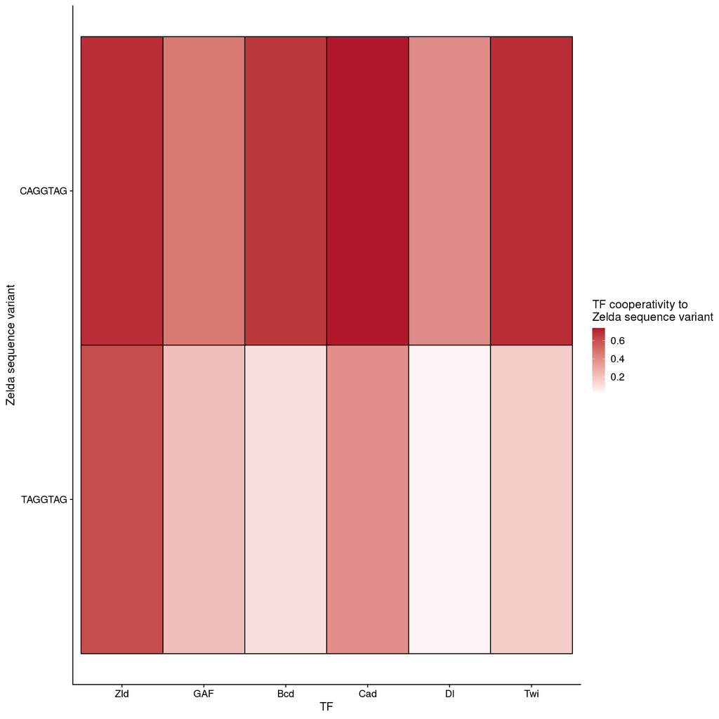

```r
# Import in silico binding cooperative information generated in 6_binding_insilico_perturbs.ipynb

bind_coop.df <- readr::read_tsv('/l/Zeitlinger/ZeitlingerLab/Manuscripts/Zelda_and_Nucleosomes/Analysis/analysis/tsv/perturbs/binding/insilico_zld_affinity_grouped_summaries.tsv.gz') %>%
  as.data.frame()

# Filter for the Zld heptads to displace

bind_coop_filter.df <- bind_coop.df[bind_coop.df$side_motif == "CAGGTAG" | bind_coop.df$side_motif == "TAGGTAG",]

# Plot

coop_order_x <- c("Zld", "GAF", "Bcd", "Cad", "Dl", "Twi")
coop_order_y <- c("TAGGTAG", "CAGGTAG")
bind_coop_filter.df$central_motif <- factor(bind_coop_filter.df$central_motif, levels = coop_order_x)
bind_coop_filter.df$side_motif <- factor(bind_coop_filter.df$side_motif, levels = coop_order_y)

coop.plot <- ggplot(bind_coop_filter.df, aes(x = central_motif, y = side_motif, fill = log2_cooperativity)) +
  geom_tile(color = 'black', size = .5) +
  scale_y_discrete(name = 'Zelda sequence variant') +
  scale_x_discrete(name = 'TF') +
  scale_fill_gradient2(name = 'TF cooperativity to\nZelda sequence variant', high = '#b2182b', low = '#2166ac', mid = 'white', midpoint = 0) +
  theme_cowplot()
coop.plot
```

```r
ggsave("insilico_injections_zld_heptads_coop.pdf", plot = coop.plot, path = "figures/12_pbm_w_affinities", height = 10, width = 20)
ggsave("insilico_injections_zld_heptads_coop.png", plot = coop.plot, path = "figures/12_pbm_w_affinities", height = 10, width = 20)
```

# 8. Conclusions